# EDA Swire Coca Cola

### **How do machine ages correlate with the frequency of maintenance requests?**

```r
# Convert EQUIP_START_UP_DATE to Date format (if not already done)
data$EQUIP_START_UP_DATE <- as.Date(data$EQUIP_START_UP_DATE, format = "%Y-%m-%d")  # Adjust format if necessary

# Create a new column for machine age using EQUIP_START_UP_DATE
data$MACHINE_AGE <- as.numeric(difftime(Sys.Date(), data$EQUIP_START_UP_DATE, units = "days"))

# Count maintenance requests by machine age
age_maintenance_counts <- data %>%
  group_by(MACHINE_AGE) %>%
  summarise(count = n(), .groups = "drop")  # Ensure to drop groups after summarising

# Check for missing values
age_maintenance_counts <- age_maintenance_counts %>%
  filter(!is.na(MACHINE_AGE) & !is.na(count))  # Remove rows with missing values

# Calculate correlation coefficient
correlation <- cor(age_maintenance_counts$MACHINE_AGE, age_maintenance_counts$count, use = "complete.obs")
print(paste("Correlation coefficient:", correlation))
```

```
[1] "Correlation coefficient: -0.00327271288994201"
```

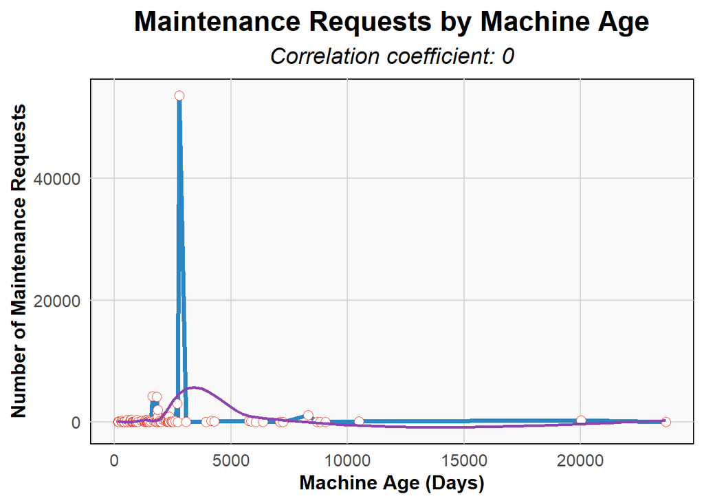

```r
# Plot the correlation between Machine Age and Frequency of Maintenance Requests
ggplot(age_maintenance_counts, aes(x = MACHINE_AGE, y = count)) +
  geom_line(color = "#2E86C1", size = 1.5) +  # Line color and thickness
  geom_point(color = "#E74C3C", size = 3, shape = 21, fill = "white") +  # Points with fill color
  geom_smooth(method = "loess", se = FALSE, color = "#8E44AD", size = 1) +  # Smoothing line color
  labs(title = "Maintenance Requests by Machine Age",
       subtitle = paste("Correlation coefficient:", round(correlation, 2)),  # Adding subtitle with correlation
       x = "Machine Age (Days)",
       y = "Number of Maintenance Requests") +
  theme_minimal(base_size = 15) +  # Base font size for better readability
  theme(
    plot.title = element_text(hjust = 0.5, size = 20, face = "bold"),  # Center title, increase size
    plot.subtitle = element_text(hjust = 0.5, size = 16, face = "italic"),  # Center subtitle
    axis.title.x = element_text(size = 14, face = "bold"),  # Bold x-axis title
    axis.title.y = element_text(size = 14, face = "bold"),  # Bold y-axis title
    axis.text = element_text(size = 12),  # Adjust axis text size
    panel.grid.major = element_line(color = "#D3D3D3", size = 0.5),  # Major grid lines color
    panel.grid.minor = element_blank(),  # Remove minor grid lines
    panel.background = element_rect(fill = "#F9F9F9")  # Light background for better contrast
  )
```

The graph shows how the age of machines at Swire Coca-Cola relates to the number of maintenance requests made. Interestingly, the correlation coefficient is close to zero (-0.00327), suggesting that there isn’t a meaningful linear relationship between the age of the machine and how often it needs maintenance. This unexpected identifying goes against the common belief that older machines need additional maintenance. The plot reveals a complicated, non-linear pattern. We’ve noticed a significant increase in maintenance requests for machines that are around 2,500-3,000 days old, which is roughly 7-8 years, and then there’s a sudden drop after that. Maintenance requests for both newer and older machines tend to be quite low and consistent. This pattern indicates that there are likely other factors at play besides age, like the type of machine, how often it’s used, or the maintenance policies in place, which could significantly influence how often maintenance is needed. The findings highlight the importance of taking a more detailed approach to predictive maintenance, looking at various factors beyond simply the age of the machine.